# Exploratory Data Analysis Project

# Univariate Plots Section

I will explore dataset of quality and attributes for 4 898 white wines

```
## [1] 4898   13
```

```
## 'data.frame':    4898 obs. of  13 variables:
##  $ X                   : int  1 2 3 4 5 6 7 8 9 10 ...
##  $ fixed.acidity       : num  7 6.3 8.1 7.2 7.2 8.1 6.2 7 6.3 8.1 ...
##  $ volatile.acidity    : num  0.27 0.3 0.28 0.23 0.23 0.28 0.32 0.27 0.3 0.22 ...
##  $ citric.acid         : num  0.36 0.34 0.4 0.32 0.32 0.4 0.16 0.36 0.34 0.43 ...
##  $ residual.sugar      : num  20.7 1.6 6.9 8.5 8.5 6.9 7 20.7 1.6 1.5 ...
##  $ chlorides           : num  0.045 0.049 0.05 0.058 0.058 0.05 0.045 0.045 0.049 0.044 ...
##  $ free.sulfur.dioxide : num  45 14 30 47 47 30 30 45 14 28 ...
##  $ total.sulfur.dioxide: num  170 132 97 186 186 97 136 170 132 129 ...
##  $ density             : num  1.001 0.994 0.995 0.996 0.996 ...
##  $ pH                  : num  3 3.3 3.26 3.19 3.19 3.26 3.18 3 3.3 3.22 ...
##  $ sulphates           : num  0.45 0.49 0.44 0.4 0.4 0.44 0.47 0.45 0.49 0.45 ...
##  $ alcohol             : num  8.8 9.5 10.1 9.9 9.9 10.1 9.6 8.8 9.5 11 ...
##  $ quality             : int  6 6 6 6 6 6 6 6 6 6 ...
```

```
##        X        fixed.acidity    volatile.acidity  citric.acid
##  Min.   :   1   Min.   : 3.800   Min.   :0.0800   Min.   :0.0000
##  1st Qu.:1225   1st Qu.: 6.300   1st Qu.:0.2100   1st Qu.:0.2700
##  Median :2450   Median : 6.800   Median :0.2600   Median :0.3200
##  Mean   :2450   Mean   : 6.855   Mean   :0.2782   Mean   :0.3342
##  3rd Qu.:3674   3rd Qu.: 7.300   3rd Qu.:0.3200   3rd Qu.:0.3900
##  Max.   :4898   Max.   :14.200   Max.   :1.1000   Max.   :1.6600
##  residual.sugar     chlorides       free.sulfur.dioxide
##  Min.   : 0.600   Min.   :0.00900   Min.   :  2.00
##  1st Qu.: 1.700   1st Qu.:0.03600   1st Qu.: 23.00
##  Median : 5.200   Median :0.04300   Median : 34.00
##  Mean   : 6.391   Mean   :0.04577   Mean   : 35.31
##  3rd Qu.: 9.900   3rd Qu.:0.05000   3rd Qu.: 46.00
##  Max.   :65.800   Max.   :0.34600   Max.   :289.00
##  total.sulfur.dioxide    density             pH          sulphates
##  Min.   :  9.0        Min.   :0.9871   Min.   :2.720   Min.   :0.2200
##  1st Qu.:108.0        1st Qu.:0.9917   1st Qu.:3.090   1st Qu.:0.4100
##  Median :134.0        Median :0.9937   Median :3.180   Median :0.4700
##  Mean   :138.4        Mean   :0.9940   Mean   :3.188   Mean   :0.4898
##  3rd Qu.:167.0        3rd Qu.:0.9961   3rd Qu.:3.280   3rd Qu.:0.5500
##  Max.   :440.0        Max.   :1.0390   Max.   :3.820   Max.   :1.0800
##     alcohol         quality
##  Min.   : 8.00   Min.   :3.000
##  1st Qu.: 9.50   1st Qu.:5.000
##  Median :10.40   Median :6.000
##  Mean   :10.51   Mean   :5.878
##  3rd Qu.:11.40   3rd Qu.:6.000
##  Max.   :14.20   Max.   :9.000
```

My dataset includes 13 variables with 4 898 observations. I think that quality is the most interesting variable in this dataset.

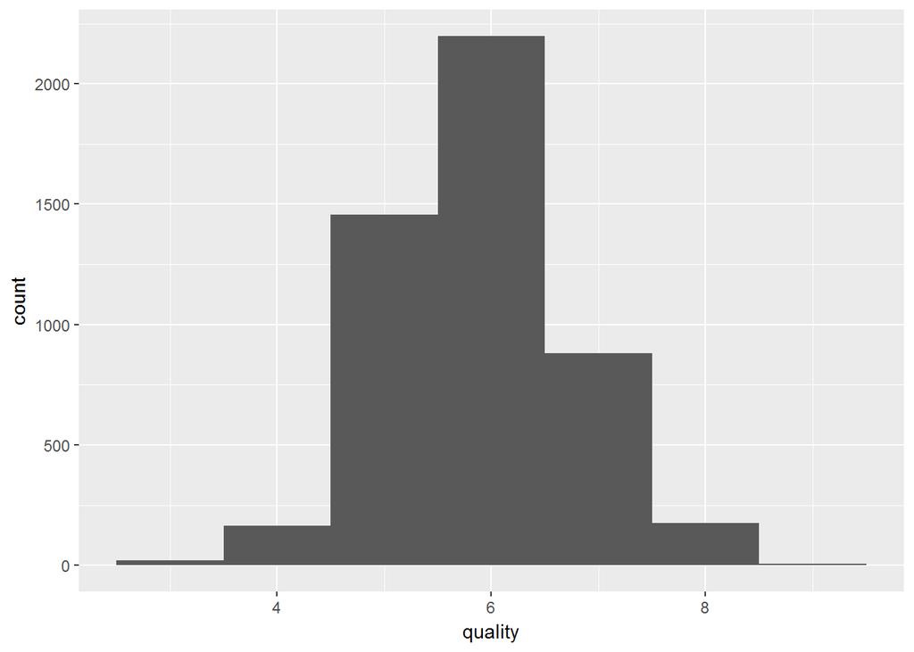

Most wines have 6 scores of quality. Sulphates, pH and alcohol are also worth of exploration

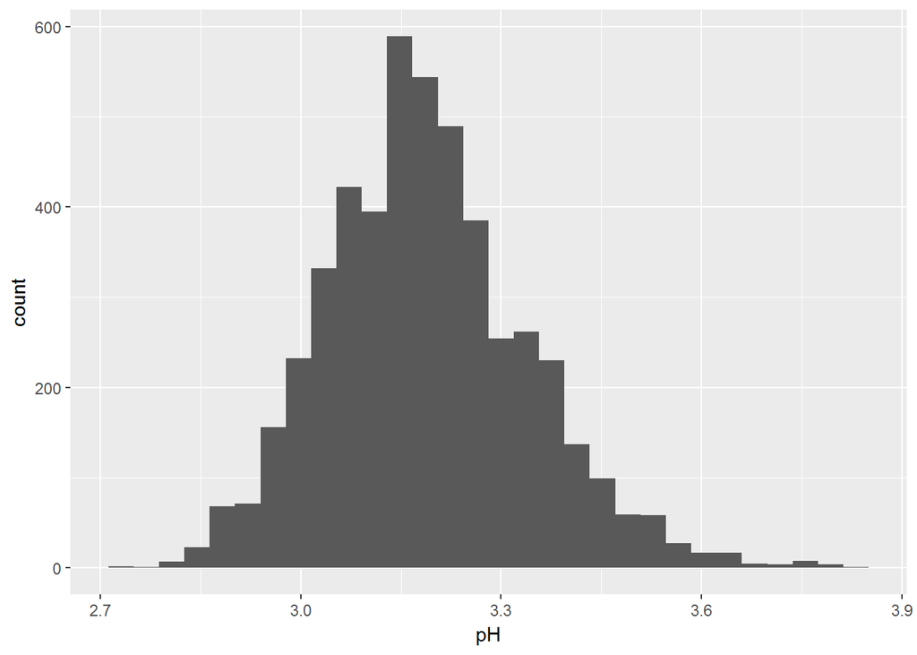

```
##    Min. 1st Qu.  Median    Mean 3rd Qu.    Max.
##   2.720   3.090   3.180   3.188   3.280   3.820
```

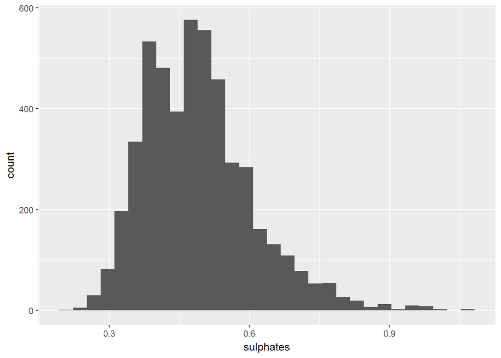

```
##    Min. 1st Qu.  Median    Mean 3rd Qu.    Max.
##  0.2200  0.4100  0.4700  0.4898  0.5500  1.0800
```

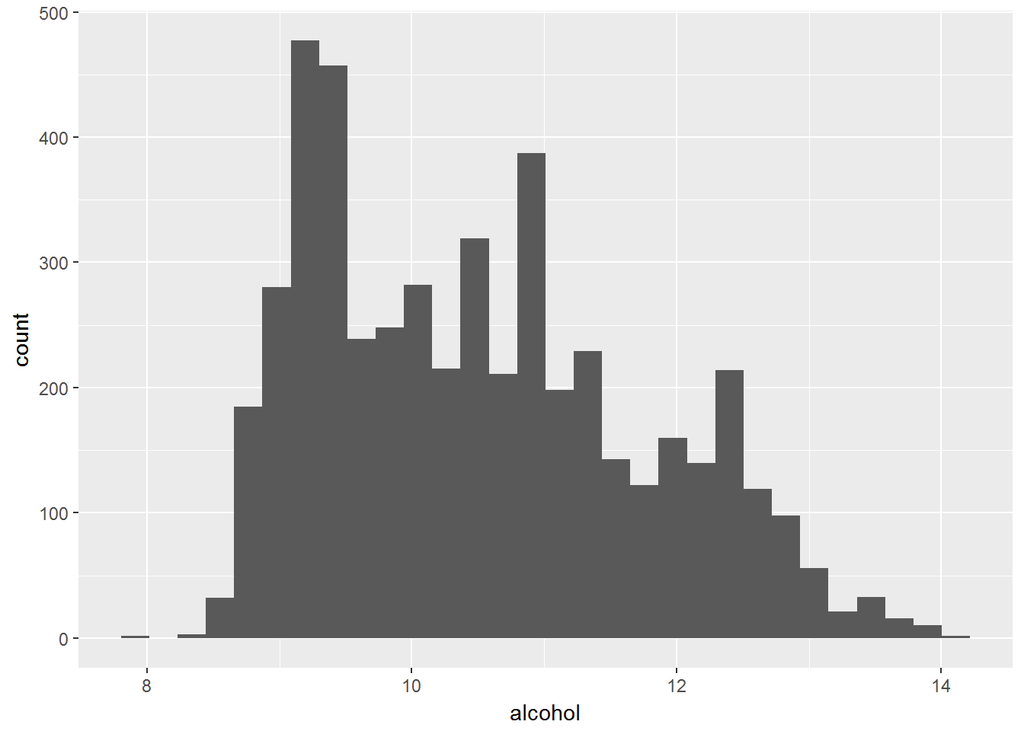

```
##    Min. 1st Qu.  Median    Mean 3rd Qu.    Max.
##    8.00    9.50   10.40   10.51   11.40   14.20
```

Most wines have approximately 3.15 pH, between 0.46 and 0.51 g/dm^3 of sulphates and 9.2 to 9.5% of alcohol.

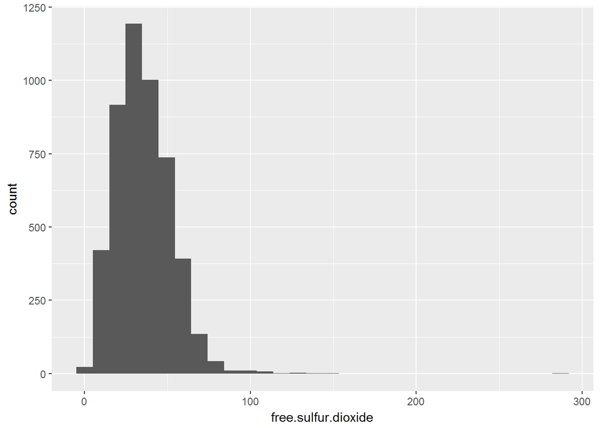

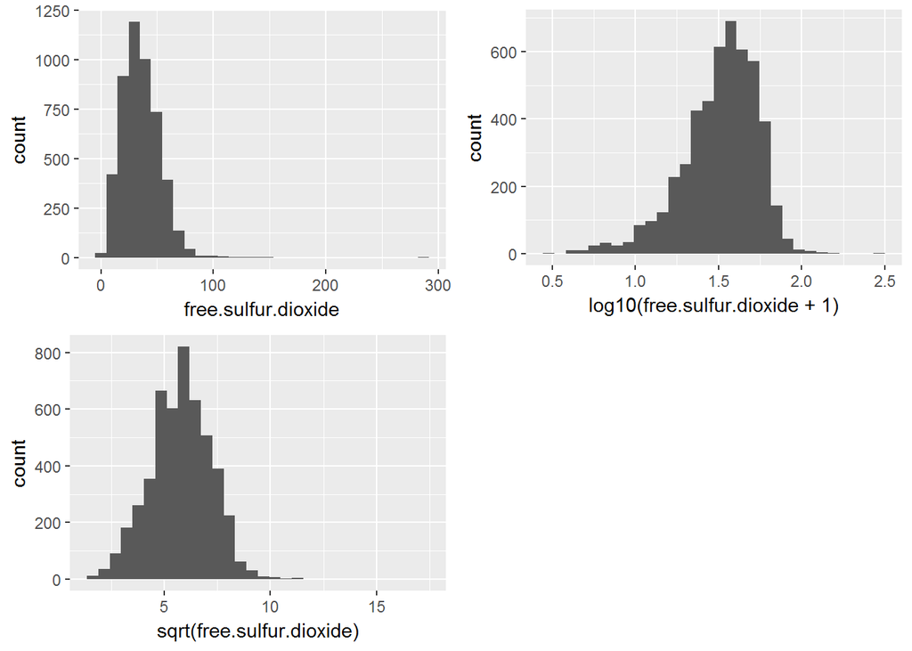

```
##    Min. 1st Qu.  Median    Mean 3rd Qu.    Max.
##    2.00   23.00   34.00   35.31   46.00  289.00
```

Most wines have free sulfur dioxide between 30 and 40 mg/dm^3.

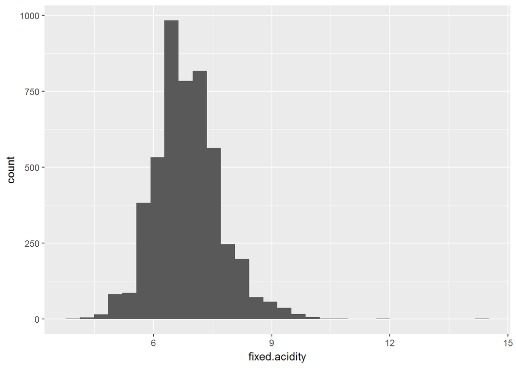

```
##    Min. 1st Qu.  Median    Mean 3rd Qu.    Max.
##   3.800   6.300   6.800   6.855   7.300  14.200
```

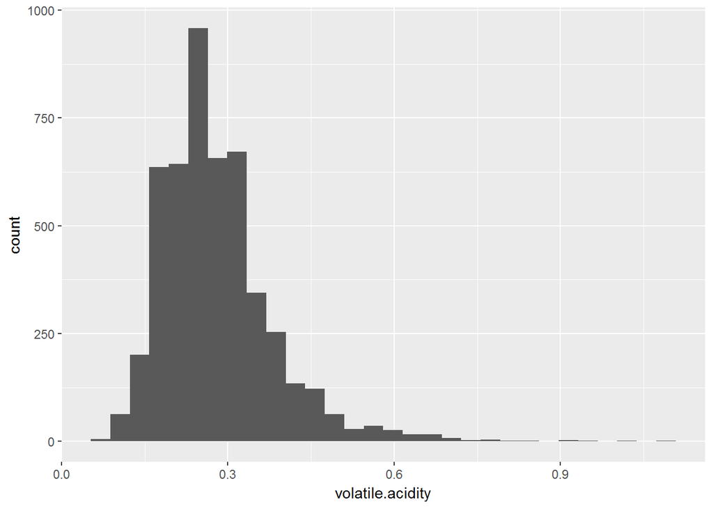

```
##    Min. 1st Qu.  Median    Mean 3rd Qu.    Max.
##  0.0800  0.2100  0.2600  0.2782  0.3200  1.1000
```

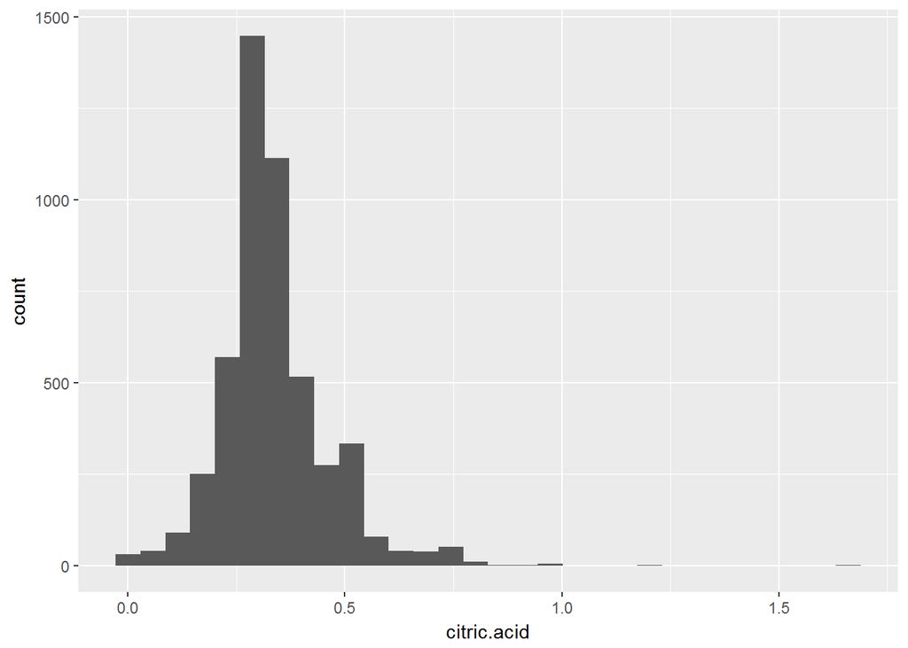

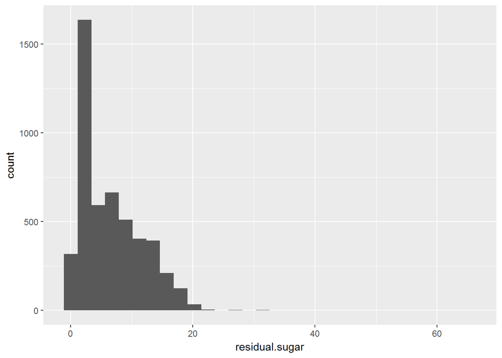

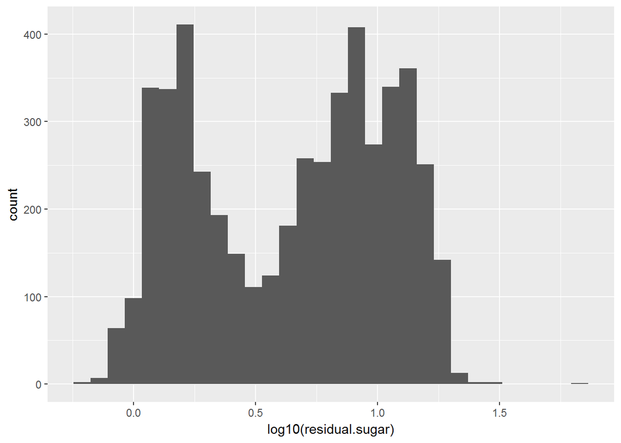

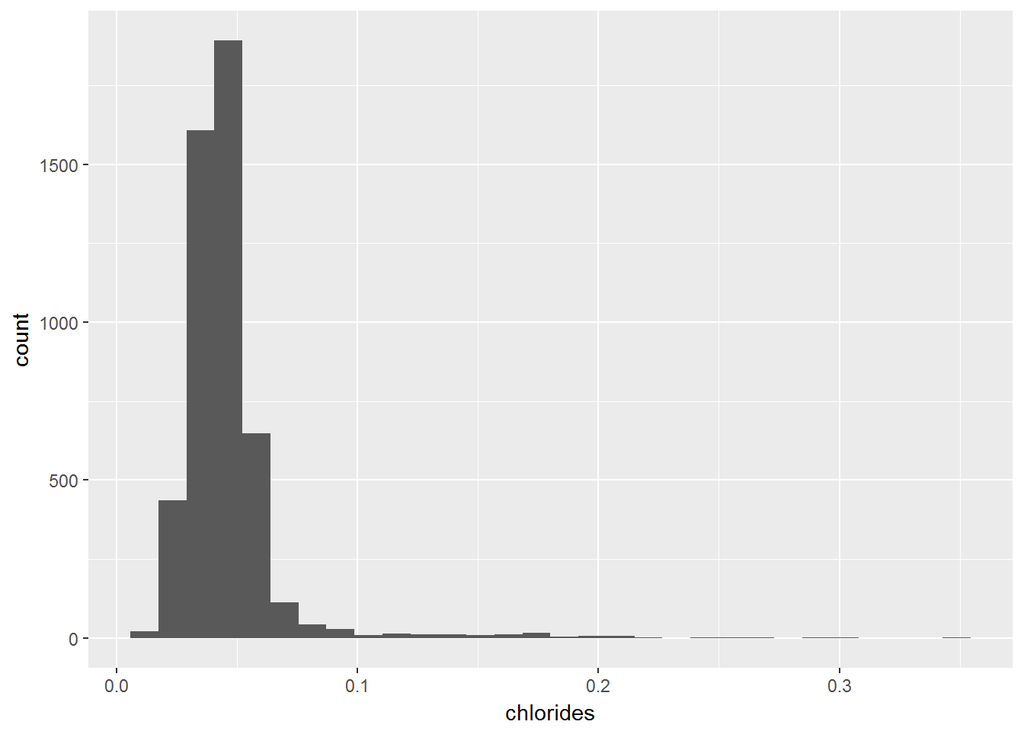

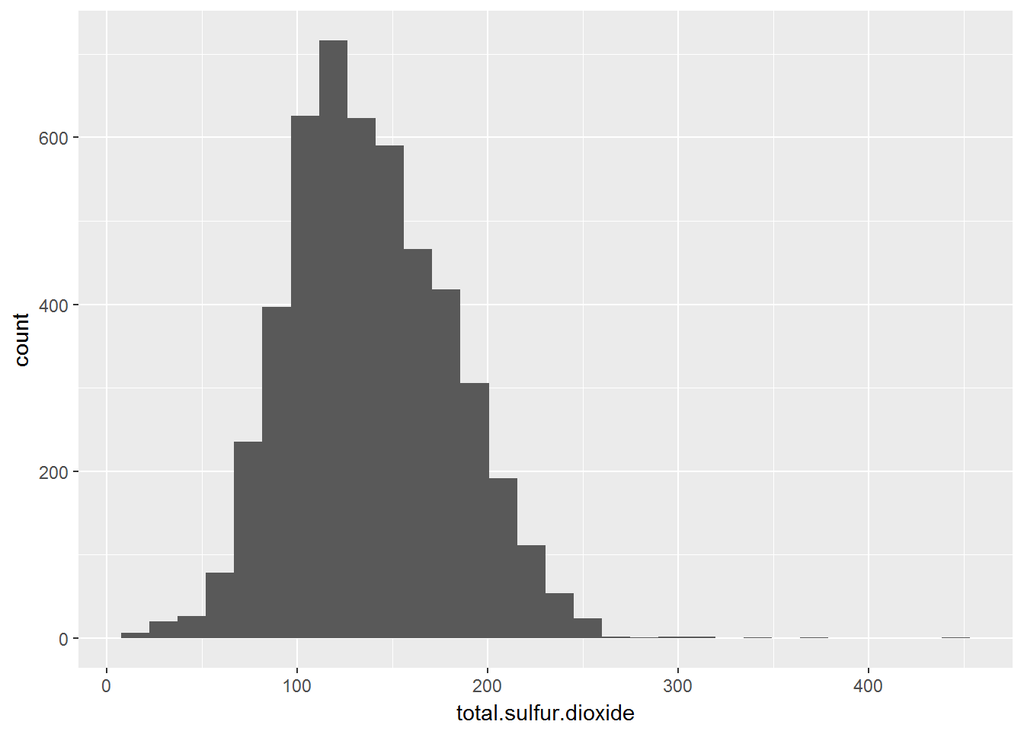

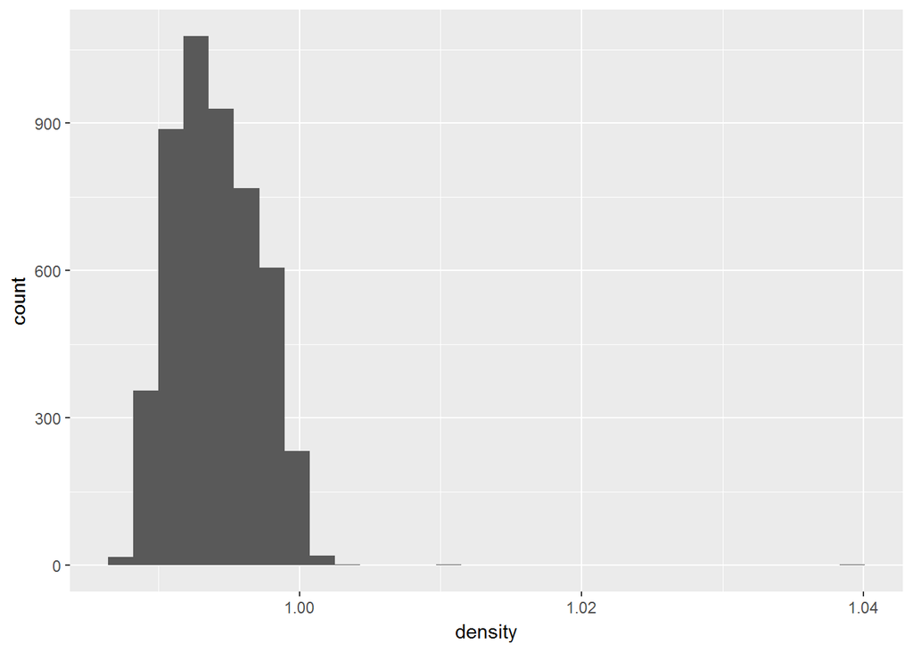

Quality of wines with high content of pH (over 3.3), sulphates (over 0.7 g/dm^3) and alcohol (over 11%).

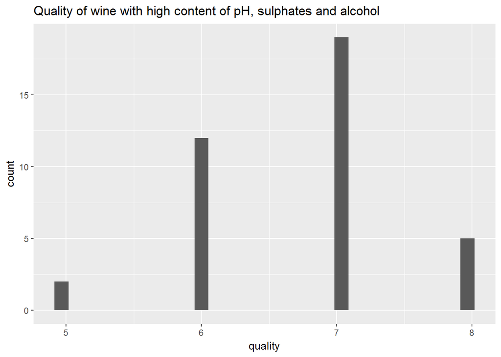

```
##    Min. 1st Qu.  Median    Mean 3rd Qu.    Max.
##   5.000   6.000   7.000   6.711   7.000   8.000
```

Quality of wines with low content of pH (below 3), sulphates (below 0.4 g/dm^3) and alcohol (below 10%).

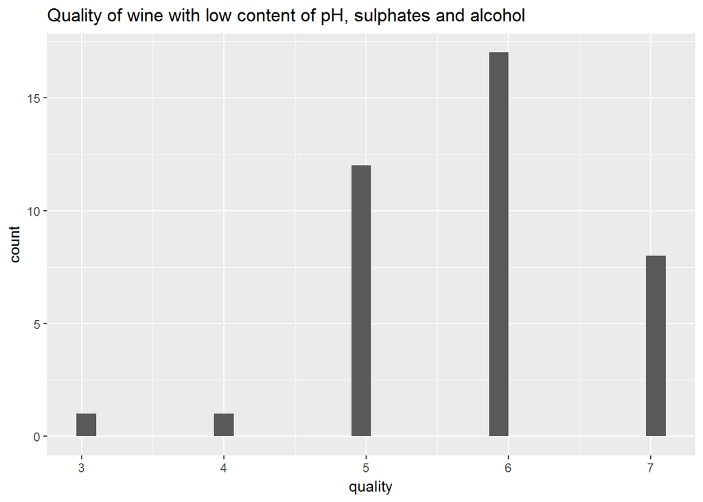

```
##    Min. 1st Qu.  Median    Mean 3rd Qu.    Max.
##   3.000   5.000   6.000   5.769   6.000   7.000
```

There is more wines with low content of pH, sulphates and alcohol but they have less quality.

# Univariate Analysis

### What is the structure of your dataset?

Dataset includes 4 898 wines with 12 features (fixed acidity, volatile acidity, citric acid, residual sugar, chlorides, free sulfur dioxide, density, pH, sulphates, alcohol and quality). All data are provided in g/dm^3 with exception of density (g/dm^3), free sulfur dioxide (mg/dm^3pH), total sulfur dioxide (mg/dm^3pH), alcohol (%) and quality (scores from 0 to 10).

Other observations:

- Most wines have 6 scores of quality.
- Most wines have 3.15 pH.
- The median sulphates is 0.47 g/dm^3.
- The median alcohol is 10.4%.
- The median free sulfur dioxide is 34.0 mg/dm^3.

# Bivariate Plots Section

```
##                     quality     pH sulphates alcohol free.sulfur.dioxide
## quality               1.000  0.099     0.054   0.436               0.008
## pH                    0.099  1.000     0.156   0.121              -0.001
## sulphates             0.054  0.156     1.000  -0.017               0.059
## alcohol               0.436  0.121    -0.017   1.000              -0.250
## free.sulfur.dioxide   0.008 -0.001     0.059  -0.250               1.000
```

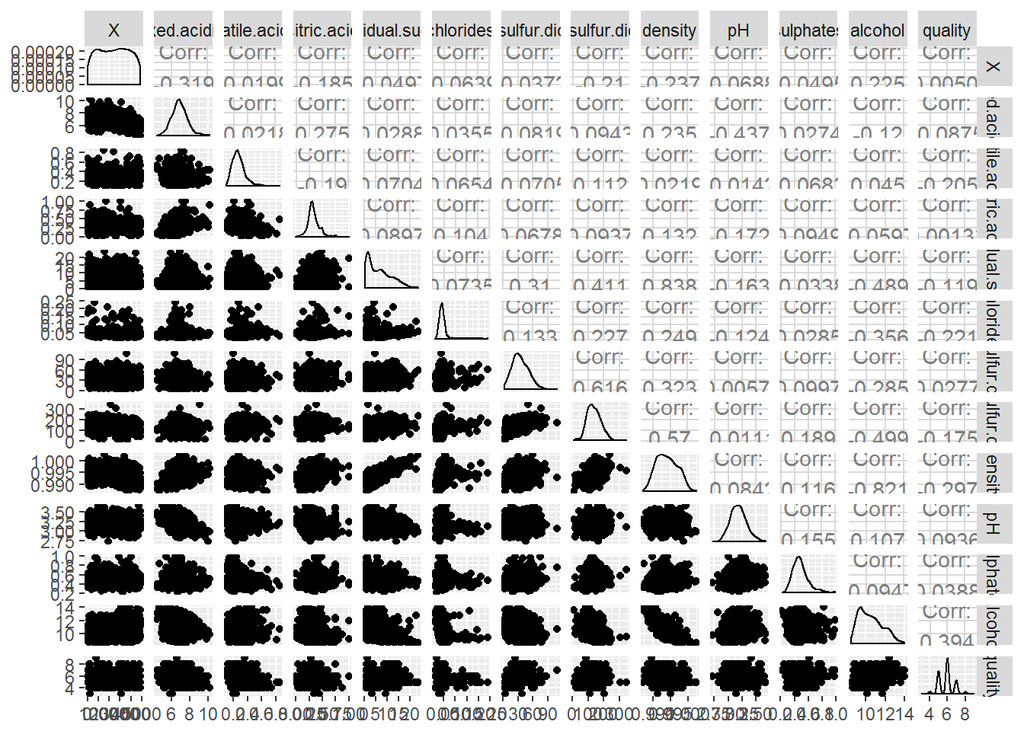

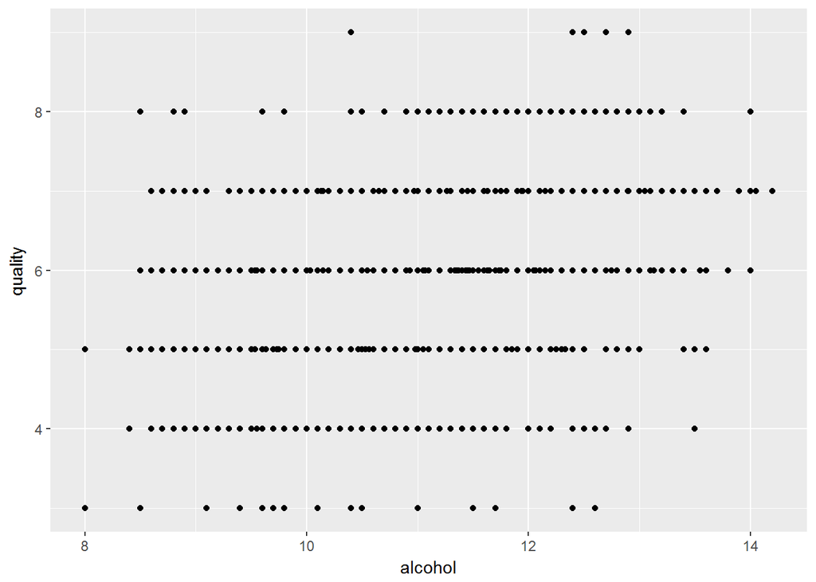

```
##
## Call:
## lm(formula = quality ~ alcohol, data = WineQuality)
##
## Residuals:
##     Min      1Q  Median      3Q     Max
## -3.5317 -0.5286  0.0012  0.4996  3.1579
##
## Coefficients:
##             Estimate Std. Error t value Pr(>|t|)
## (Intercept) 2.582009   0.098008   26.34   <2e-16 ***
## alcohol     0.313469   0.009258   33.86   <2e-16 ***
## ---
## Signif. codes:  0 '***' 0.001 '**' 0.01 '*' 0.05 '.' 0.1 ' ' 1
##
## Residual standard error: 0.7973 on 4896 degrees of freedom
## Multiple R-squared:  0.1897, Adjusted R-squared:  0.1896
## F-statistic:  1146 on 1 and 4896 DF,  p-value: < 2.2e-16
```

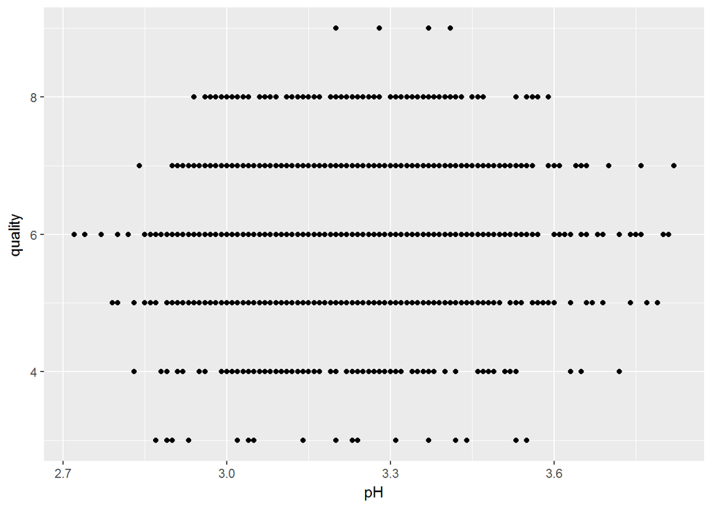

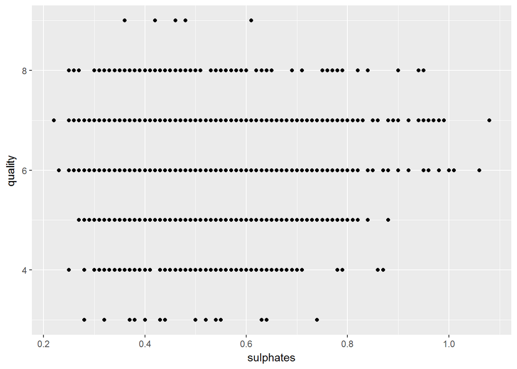

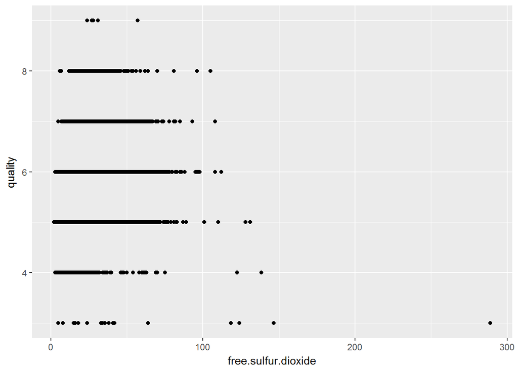

pH, sulphates and free sulfur dioxide don’t seem to have relevant influence on wine’s quality.

```
##                           X fixed.acidity volatile.acidity citric.acid
## X                     1.000        -0.256            0.003      -0.150
## fixed.acidity        -0.256         1.000           -0.023       0.289
## volatile.acidity      0.003        -0.023            1.000      -0.149
## citric.acid          -0.150         0.289           -0.149       1.000
## residual.sugar        0.007         0.089            0.064       0.094
## chlorides            -0.046         0.023            0.071       0.114
## free.sulfur.dioxide  -0.012        -0.049           -0.097       0.094
## total.sulfur.dioxide -0.162         0.091            0.089       0.121
## density              -0.186         0.265            0.027       0.150
## pH                   -0.116        -0.426           -0.032      -0.164
## sulphates             0.010        -0.017           -0.036       0.062
## alcohol               0.214        -0.121            0.068      -0.076
## quality               0.036        -0.114           -0.195      -0.009
##                      residual.sugar chlorides free.sulfur.dioxide
## X                             0.007    -0.046              -0.012
## fixed.acidity                 0.089     0.023              -0.049
## volatile.acidity              0.064     0.071              -0.097
## citric.acid                   0.094     0.114               0.094
## residual.sugar                1.000     0.089               0.299
## chlorides                     0.089     1.000               0.101
## free.sulfur.dioxide           0.299     0.101               1.000
## total.sulfur.dioxide          0.401     0.199               0.616
## density                       0.839     0.257               0.294
## pH                           -0.194    -0.090              -0.001
## sulphates                    -0.027     0.017               0.059
## alcohol                      -0.451    -0.360              -0.250
## quality                      -0.098    -0.210               0.008
##                      total.sulfur.dioxide density     pH sulphates alcohol
## X                                  -0.162  -0.186 -0.116     0.010   0.214
## fixed.acidity                       0.091   0.265 -0.426    -0.017  -0.121
## volatile.acidity                    0.089   0.027 -0.032    -0.036   0.068
## citric.acid                         0.121   0.150 -0.164     0.062  -0.076
## residual.sugar                      0.401   0.839 -0.194    -0.027  -0.451
## chlorides                           0.199   0.257 -0.090     0.017  -0.360
## free.sulfur.dioxide                 0.616   0.294 -0.001     0.059  -0.250
## total.sulfur.dioxide                1.000   0.530  0.002     0.135  -0.449
## density                             0.530   1.000 -0.094     0.074  -0.780
## pH                                  0.002  -0.094  1.000     0.156   0.121
## sulphates                           0.135   0.074  0.156     1.000  -0.017
## alcohol                            -0.449  -0.780  0.121    -0.017   1.000
## quality                            -0.175  -0.307  0.099     0.054   0.436
##                      quality
## X                      0.036
## fixed.acidity         -0.114
## volatile.acidity      -0.195
## citric.acid           -0.009
## residual.sugar        -0.098
## chlorides             -0.210
## free.sulfur.dioxide    0.008
## total.sulfur.dioxide  -0.175
## density               -0.307
## pH                     0.099
## sulphates              0.054
## alcohol                0.436
## quality                1.000
```

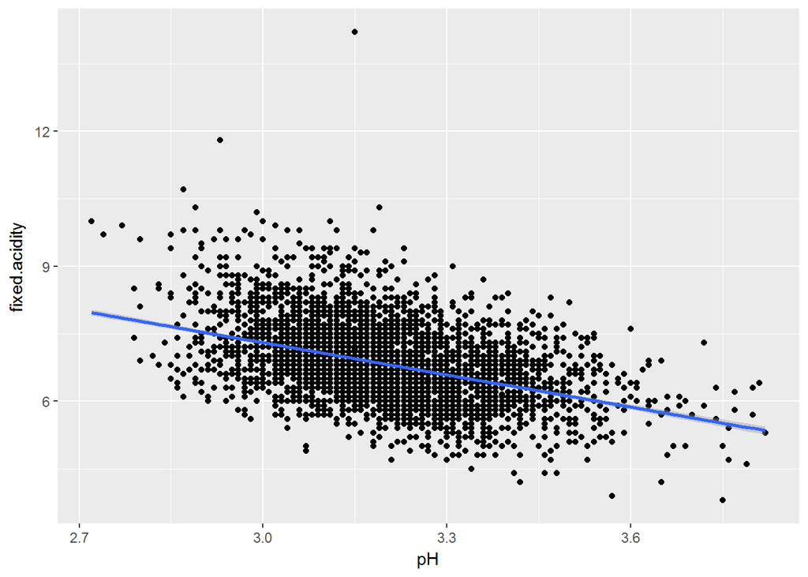

Fixed acidity is inversely proportional to pH.

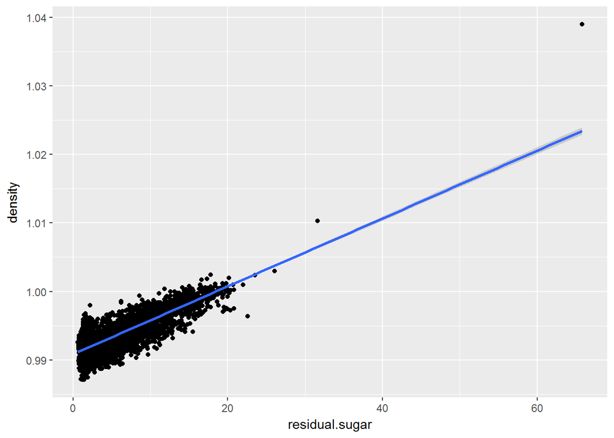

I can see also linear relationship between residual sugar and density.

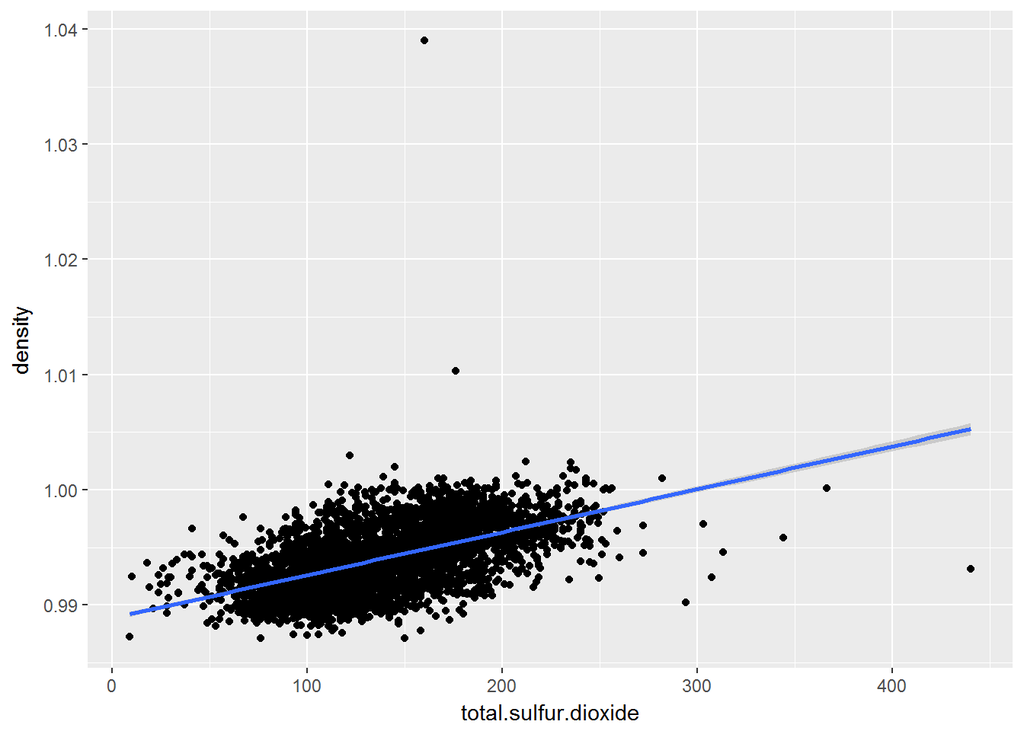

Also density seems to increase with total sulfur dioxide’s increment.

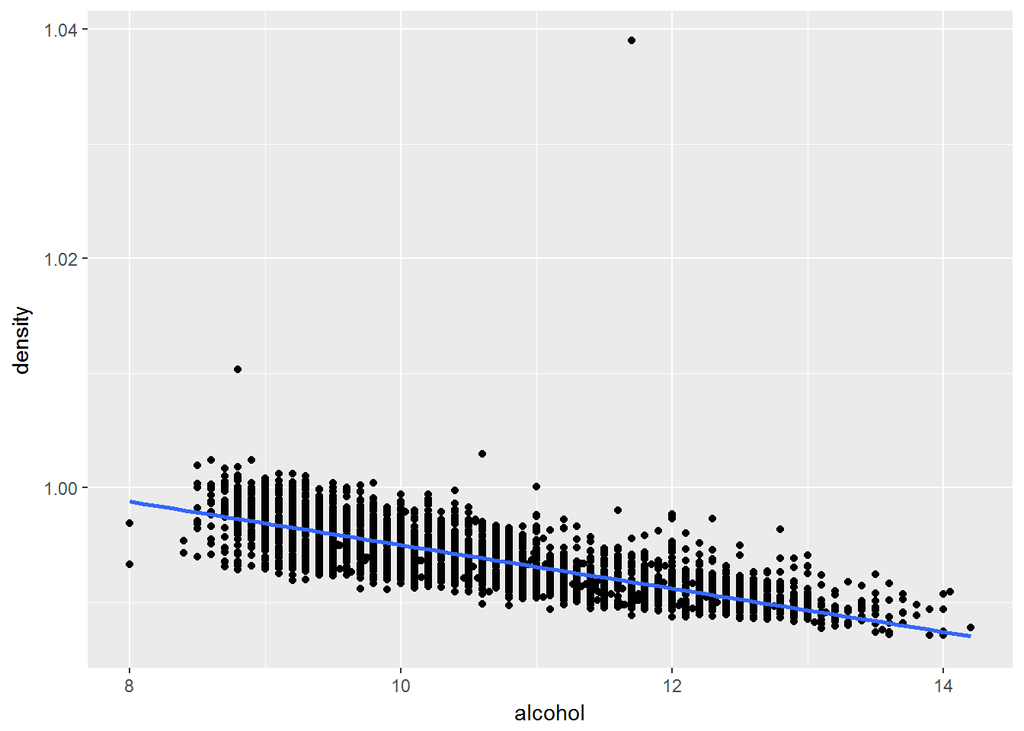

On the contrary, density decrese with alcohol’s increment.

# Bivariate Analysis

### Did you observe any interesting relationships between the other features (not the main feature(s) of interest)?

I noticed inverse proportion between pH and fixed acidity but also between density and alcohol. There is also linear relationship between residual sugar and density. Although density grow when total sulfur dioxide grow.

### What was the strongest relationship you found?

The strongest relationship is, definitly between residual sugar and density.

# Multivariate Plots Section

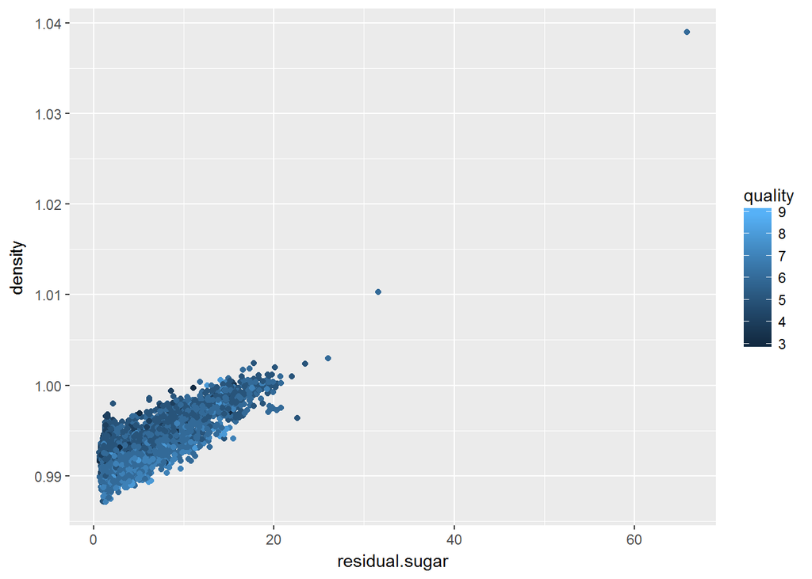

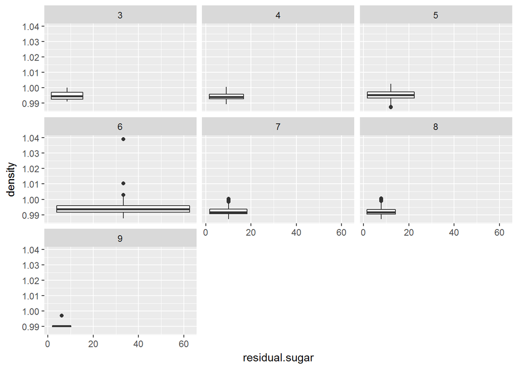

Wines with the worst quality have high density and the best wines have low density.

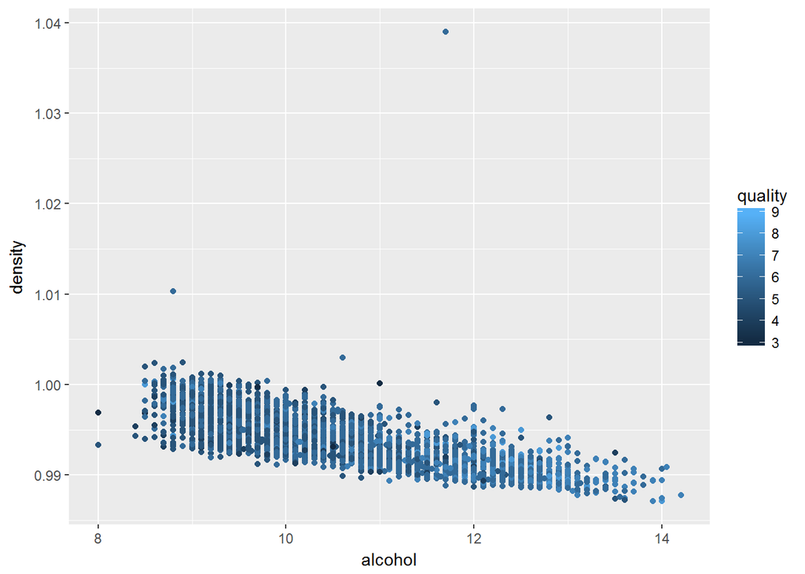

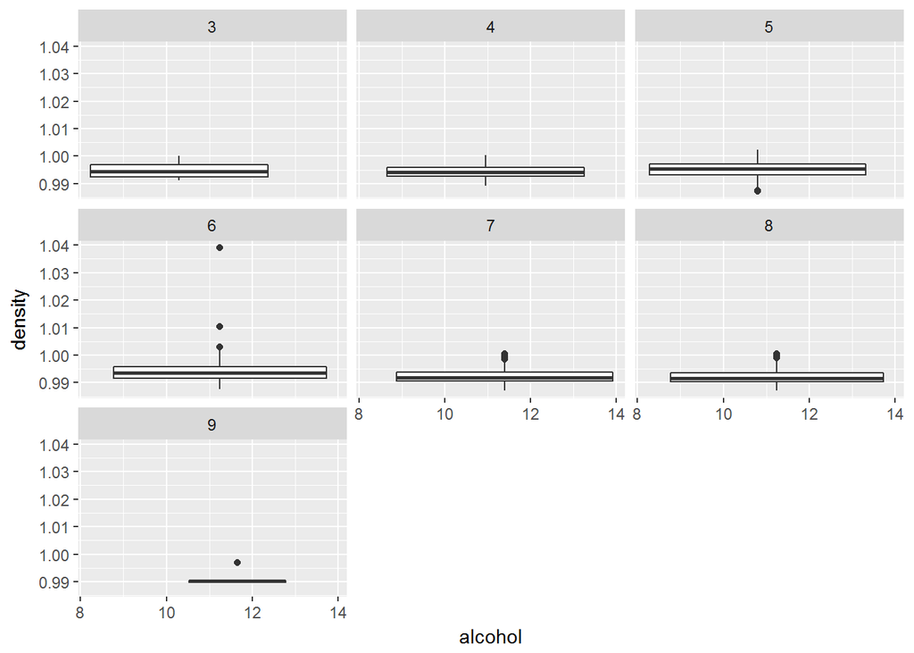

The best wines have from 10 to 13% alcohol. The worst wines have from 8% to 12% alcohol.

# Multivariate Analysis

### Talk about some of the relationships you observed in this part of the investigation. Were there features that strengthened each other in terms of looking at your feature(s) of interest?

# Reflection

To sum up, I can tell that experts evaluate quality of wine on the base of their own preferences. I noticed strong relationships between residual sugar and density but also between alcohol and density.